# 1 Module 1 - Encapsulation

### 5.3.6 The Prototype Design Pattern

One use of polymorphic copying is to support the design of a class that specializes in the creation of objects. Consider the toolbar in JetUML.

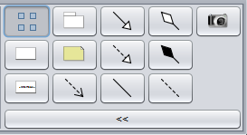

The buttons on the panel all basically do the same thing: place an object on the diagram. The only thing that changes for different buttons is the type of graph node that gets *created*. So it would be desirable, from a code reuse point of view, to have only one class that can handle the creation of any kind of button. In the actual design, the toolbar is implemented by class [Toolbar](https://github.com/prmr/JetUML/blob/v1.0/src/ca/mcgill/cs/stg/jetuml/framework/ToolBar.java) which manages the button and has a method that can return what "tool" is selected. The class *does not* manage the creation of any `Node` objects, but instead can return *the type of node* that corresponds to the button that is selected:

```java
public GraphElement getSelectedTool()
```

Whenever a user clicks a button on the toolbar, the code that responds to the input from the user can now simply create the new node by cloning it:

```java
private void handleNodeCreation(MouseEvent pEvent)
{
   Node newNode = ((Node)aSideBar.getSelectedTool()).clone();
   boolean added = aGraph.addNode(newNode, getMousePoint(pEvent));
   ...
```

This is the idea of using a **prototype object**. Here the toolbar can provided a prototype object to the part of the program in charge of adding a `GraphElement` to the diagram, and to accomplish this task the client code can simply clone the prototype object. A simpler, synthetic example that summarizes this idea is illustrated with class `ElementCreator`:

```java
public class ElementCreator
{
   private Element aPrototype = null;

   public static void main(String[] args)
   {
      ElementCreator creator = new ElementCreator();
      creator.setPrototype(new ElementA());
      System.out.println(creator.create().description());
      creator.setPrototype(new ElementB());
      System.out.println(creator.create().description());
   }

   public void setPrototype(Element pElement)
   {
      aPrototype = pElement;
   }

   public Element create()
   {
      return aPrototype.clone();
   }
}

interface Element extends Cloneable
{
   Element clone();
   String description();
}

class ElementA implements Element
{
   public String description() { return "A"; }
   public ElementA clone()
   {
      try { return (ElementA) super.clone(); } catch( CloneNotSupportedException e ) { return null; }
   }
}

class ElementB implements Element
{
   public String description() { return "B"; }
   public ElementA clone()
   {
      try { return (ElementA) super.clone(); } catch( CloneNotSupportedException e ) { return null; }
   }
}
```

In this code example, an instance of `ElementCreator` is capable of creating any number of new objects of any type that is a subtype of `Element`. To enable the creation of new objects, the `ElementCreator` instance must store a reference to a prototype object. Once this prototype is available, it is possible to create new objects simply by cloning the prototype. It is also be possible to change the prototype during the life-cycle of an `ElementCreator` instance, so that whatever is created by calling `create()` can also change. The idea of using a prototype object to manage the creation of new object of a statically undefined type is referred to as the **Prototype Design Pattern**.

### 5.3.7 The Command Design Pattern

Conceptually a command is a piece of code that accomplishes something: saving a file, adding a node to a diagram, etc. Intuitively the way to represent a command in a program easily maps to the concept of a function or method, since that is an abstraction that corresponds to a piece of code that will execute. However, an often-useful design idiom is to instead use an entire object to represent a command and to act on commands polymorphically. The UML Class Diagram below shows how this can be achieved.

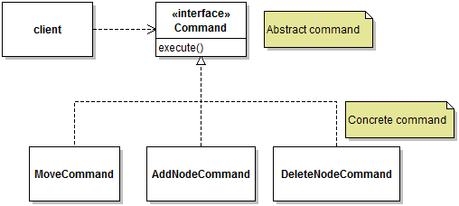

In this design a client interacts with **abstract commands** represented by the `Command` interface. To execute a command, the client simply calls method `execute()` on an object of type `Command`, and the implementation of `execute` in the corresponding **concrete command** gets selected polymorphically.

### 5.3.8 The Law of Demeter

When designing a piece of software using the principle of delegation, one can often end up with long delegation chains between objects. For example, in the Solitaire application, we could have the following situation:

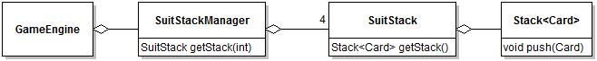

In this design, a `GameEngine` object holds a reference to an instance of `SuitStackManager` to manage the four stacks of cards of a single suit. In turn, a `SuitStackManager` holds references to four `SuitStack` instances, which are specialized wrappers around `Stack` objects, etc.

There are different ways to use such delegation chains. Let's consider the scenario of adding a card to a suit stack. One way is illustrated as follows:

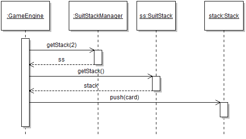

In this design the `GameEngine` is in charge of all the details of adding a card to a stack, and must handle every intermediate object in the delegation chain. This design violates the principle of *information hiding* by requiring the code of the `GameEngine` class to know about the precise navigation structure required to add a card to the system. The intuition that designs such as this one tend to be suboptimal is captured by the [Law of Demeter](https://en.wikipedia.org/wiki/Law_of_Demeter). The "law" of Demeter is actually a design guideline that states that the code of a method should only access: * The instance variables of its implicit parameter; * The arguments passed to the method; * Any new object created within the method; * (If need be) globally available objects.

So, to respect this guideline it becomes necessary to provide additional services in classes that occupy an intermediate position in a delegation chain so that the clients do not need to manipulate the internal objects encapsulated by these objects. The solution in our example would be:

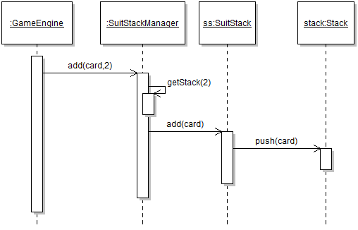

In this solution, objects do not return references to their internal structure, but instead provide the complete service required by the client at each step in the delegation chain.

## 5.4 Reading

- [Module 5 Code Samples](https://github.com/prmr/SoftwareDesignCode/tree/master/module05/ca/mcgill/cs/swdesign/m5)
- JetUML v1.0: The [ToolBar](https://github.com/prmr/JetUML/blob/v1.0/src/ca/mcgill/cs/stg/jetuml/framework/ToolBar.java) class and its [design docs](https://github.com/prmr/JetUML/blob/v1.0/doc/functional/toolbar.md) show a near-classic implementation of the Prototype design pattern.
- Solitaire v0.3 implements the Command pattern though interface [Move](https://github.com/prmr/Solitaire/blob/v0.3/src/ca/mcgill/cs/stg/solitaire/model/Move.java)
- Solitaire v0.3 implements the Composite pattern though class [CompositeMove](https://github.com/prmr/Solitaire/blob/master/src/ca/mcgill/cs/stg/solitaire/model/CompositeMove.java)

## 5.5 Exercises

Exercises prefixed with :star: are optional, more challenging questions aimed to provide you with additional design and programming experience. Exercises prefixed with :spades: will incrementally guide you towards the ultimate completion of a complete Solitaire application.

For maximum learning effectiveness, I recommend peeking at the answers only after giving the problems an honest try.

1. Draw a UML Sequence Diagram to represent the following program. Consider that the `main` method can be approximated as an object with name `client`:

```java
public static void main(String[] args)
{
   String string1 = "Foo";
   String string2 = "Bar";
   System.out.println(string1.compareTo(string2));
}
```

1. Study the code of method [`GameModel.undoLast()`](https://github.com/prmr/Solitaire/blob/v0.4/src/ca/mcgill/cs/stg/solitaire/model/GameModel.java#L279) in the Solitaire application and create a UML sequence diagram to model the key object interactions in this method. Note that this and similar code exploration questions will be much easier and more enjoyable to complete using a clone of the project workspace.
2. Study the code of method [`EditorFrame.cut()`](https://github.com/prmr/JetUML/blob/v1.1/src/ca/mcgill/cs/stg/jetuml/framework/EditorFrame.java#L702) in JetUML and create a UML sequence diagram to model the key object interactions in this method.
3. Make the [Hand](https://github.com/prmr/SoftwareDesignCode/tree/master/module02/ca/mcgill/cs/swdesign/m2/Hand.java) class cloneable. Write a small driver program that creates a new `Hand` object and clones it. Create a UML object diagram to represent a cloned Hand. Use the debugger to verify the correctness of your diagram.
4. Starting from the [Module 5 Code Samples](https://github.com/prmr/SoftwareDesignCode/tree/master/module05/ca/mcgill/cs/swdesign/m5), implement method `clone` in class `ConferenceShow`.
5. Starting from the [Module 5 Code Samples](https://github.com/prmr/SoftwareDesignCode/tree/master/module05/ca/mcgill/cs/swdesign/m5), enhance the design with the concept of a composite command, and use this feature to implement a command that clears the program and adds one show to the fresh program.
6. Starting from the [Module 5 Code Samples](https://github.com/prmr/SoftwareDesignCode/tree/master/module05/ca/mcgill/cs/swdesign/m5), enhance the design with the concept of a "logged command" that logs any kind of command to the console after having executed it.
7. Design a `CompositeIcon` class that can contain multiple icons. Note that a standard application of the Composite design pattern will result in the composed icons being painted on top of each other. Solve this problem with a `ShiftedIcon` decorator that will support drawing an icon as shifted by (parametric) x and y values. Extend the following diagram to complete the design. Make sure you list all the methods (including constructors) that will be necessary to make this work.

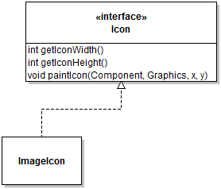

1. Draw a sequence diagram showing what happens to a composite icon after a painIcon callback.
2. Implement the solution using the [module's source code samples](https://github.com/prmr/SoftwareDesignCode/tree/master/module05/ca/mcgill/cs/swdesign/m5/icon) as a template. When you solve this exercise, executing the main method of the `BridgeDealer` class should show a graphical window where card icons are laid out according to your solution.
3. :star: Write unit tests for the `getIconHeight()` and `getIconWidth()` method using stubs.
4. Study the code of the [Solitaire](https://github.com/prmr/Solitaire/tree/v0.4) application and draw a UML class diagram that shows how the Command design pattern is used to support game `Move`s.

## 5.6 Answers

Answers and answer sketches to the Module 5 practice exercises.

### 5.6.1 Exercise 1

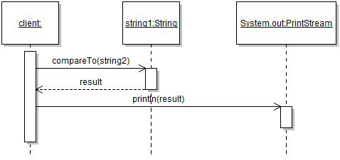

Note that the diagram skips over the initialization of the two `String` objects, which in any case is done under the covers by the compiler because of the use of string literals. It's also interesting to note that the object referenced by `string2` does *not* participate in the sequence at the level of abstraction modeled here. Finally, detailed calls to library methods are not normally part of sequence diagrams, but here it was interesting to show what the common `println` statement maps to.

### 5.6.2 Exercise 2

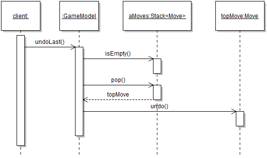

Things to note from this diagram:

- The use of the somewhat "fake" `client` object provides a nice way to provide the context of the object sequence (that is, where the sequence occurs in the code);
- The diagram does not include any detailed code logic, for example the fact that the bottom part of the sequence only occurs if `isEmpty()` returns `false`. That is not the point of a model. People who need that level of detail should look at the code directly.
- The appropriate use of names really increases the clarity of the model. For example, here I annotated the return edge with the label `topMove`, then gave this name to the object of type `Move`. From this it should be fairly clear that it's the top move that's being undone, without having to rely of diagram notation.

### 5.6.3 Exercise 3

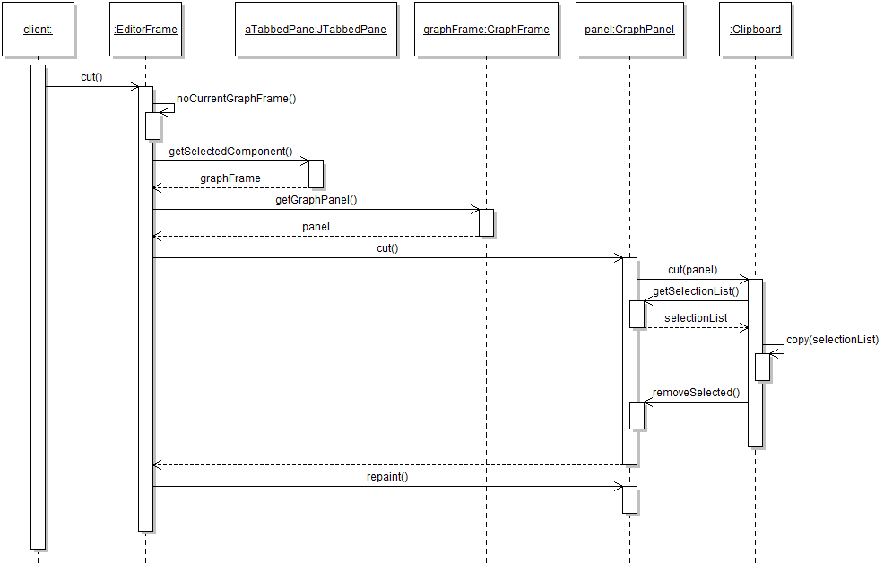

With this question we finally reached a level of complexity where the value of UML models starts to become more apparent. Here with a minimum of experience a developer would be able to see from the left of the diagram that the `EditorFrame` takes care for a bunch of object navigation and access, and from the right of the diagram that that actual `cut` functionality is realized through a close collaboration between an instance of `GraphPanel` and an instance of `Clipboard`.

### 5.6.4 Exercise 4

The class must be declared to implement `Cloneable`, and supply a `clone` method. Here we assume that it's acceptable to make a shallow copy of the card objects, since they are immutable and either unique or systematically tested for equality using `equals`. It would also have been a correct answer to deep-copy the card objects, since the design does not require them to be unique.

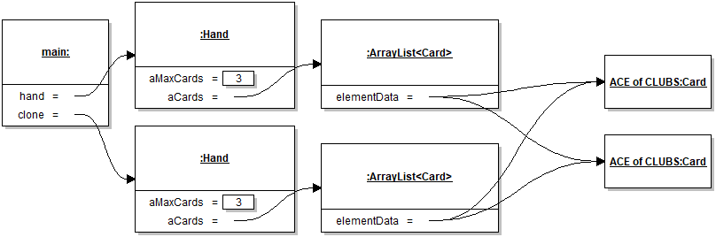

```java
public class Hand implements Iterable<Card>, Cloneable
{
   ...
   @Override
   public Hand clone()
   {
      try
      {
         Hand clone = (Hand) super.clone();
         clone.aCards = new ArrayList<>();
         for( Card card : aCards )
         {
            clone.add(card);
         }
         return clone;
      }
      catch(CloneNotSupportedException e)
      {
         return null;
      }
   }
```

### 5.6.5 Exercise 5

Here a deep copy of the decorated object is required, otherwise there would be two distinct decorators decorating the same object. To achieve multi-decoration, the proper way is to nest decorators.

```java
@Override
public ConferenceShow clone()
{
   try
   {
      ConferenceShow clone = (ConferenceShow) super.clone();
      clone.aDecorated = aDecorated.clone();
      return clone;
   }
   catch (CloneNotSupportedException e)
   {
      return null;
   }
}
```

### 5.6.6 Exercise 6

Here I chose to create a separate class for the `CompositeCommand`, since there is no issue with leaking references if they are already well-encapsulated into the component commands.

```java
public class CompositeCommand implements Command
{
   private List<Command> aCommands = new ArrayList<>();

   public CompositeCommand(Command... pCommands )
   {
      for( Command command : pCommands )
      {
         aCommands.add(command);
      }
   }

   @Override
   public void execute()
   {
      for( Command command : aCommands )
      {
         command.execute();
      }
   }
}
```

The final piece is to implement a factory for different types of composite commands, for example a `resetAndAdd` command:

```java
public class Program
{
   // Some code

   public void resetAndAdd(Show pShow, Day pDay)
   {
      assert pShow != null && pDay != null;
      Command command = new CompositeCommand(
            () -> Arrays.fill(aShows, NullShow.DEFAULT),
            () -> aShows[pDay.ordinal()] = pShow.clone());
      aCommands.add(command);
      command.execute();
   }
```

### 5.6.7 Exercise 7

We define a decorator class as follows:

```java
public class LoggedCommand implements Command
{
    private final Command aCommand;
    private final String aMessage;

    public LoggedCommand(Command pCommand, String pMessage)
    {
        aCommand = pCommand;
        aMessage = pMessage;
    }

    @Override
    public void execute()
    {
        aCommand.execute();
        // Decoration
        System.out.println(String.format("Executed command %s", aMessage));
    }
}
```

and to log a certain command, we wrap it as follows:

```java
public class Program
{
   // Some code

   public void add(Show pShow, Day pDay)
   {
      assert pShow != null && pDay != null;
      Command command = new LoggedCommand(() -> aShows[pDay.ordinal()] = pShow.clone(), "ADD");
      aCommands.add(command);
      command.execute();
   }
```

Here, overriding `toString()` in the various classes in the sample code would open up a whole range of possibilities for logging commands with more useful information.

### 5.6.8 Exercise 8

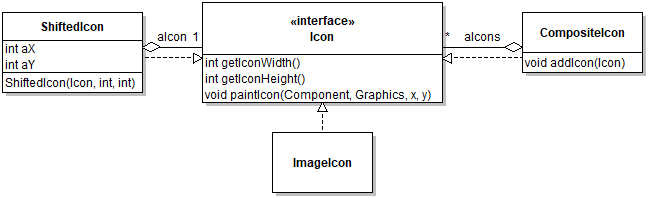

### 5.6.9 Exercise 9

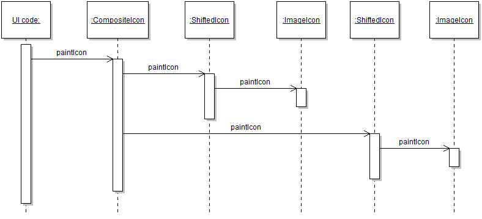

### 5.6.10 Exercise 10

You will need two new classes, a `CompositeIcon` and a `ShiftedIcon`.

```java
public class CompositeIcon implements Icon
{
   private final List<Icon> aIcons = new ArrayList<>();

   public void addIcon(Icon pIcon)
   {
      aIcons.add(pIcon);
   }

   @Override
   public int getIconHeight()
   {
      int max = 0;
      for( Icon icon : aIcons )
      {
         max = Math.max(max, icon.getIconHeight());
      }
      return max;
   }

   @Override
   public int getIconWidth()
   {
      int max = 0;
      for( Icon icon : aIcons )
      {
         max = Math.max(max, icon.getIconWidth());
      }
      return max;
   }

   @Override
   public void paintIcon(Component pComponent, Graphics pGraphics, int pX, int pY)
   {
      for( Icon icon : aIcons )
      {
         icon.paintIcon(pComponent, pGraphics, pX, pY);
      }
   }
}
```

```java
public class ShiftedIcon implements Icon
{
   private final Icon aShiftedIcon;
   private final int aX;
   private final int aY;

   public ShiftedIcon(Icon pIcon, int pX, int pY)
   {
      aShiftedIcon = pIcon;
      aX = pX;
      aY = pY;
   }


   @Override
   public int getIconHeight()
   {
      return aShiftedIcon.getIconHeight() + aY;
   }

   @Override
   public int getIconWidth()
   {
      return aShiftedIcon.getIconWidth() + aX;
    }

   @Override
   public void paintIcon(Component pComponent, Graphics pGraphics, int pX, int pY)
   {
      aShiftedIcon.paintIcon(pComponent, pGraphics, pX + aX, pY + aY);
   }
}
```

With these two working it's just a matter of creating the desired icon within the constructor and callback in `HandPanel`:

```java
HandPanel()
{
   setBackground(CASINO_GREEN);
   add(aLabel);
   CompositeIcon icon = new CompositeIcon();
   for( int i = 0; i < 13; i++ )
   {
      icon.addIcon(new ShiftedIcon(CardImages.getBack(), 20*i, 5 * i));
   }
   aLabel.setIcon(icon);
}

public void showHand(Card[] pHand)
{
   Deck deck = new Deck();
   deck.shuffle();
   CompositeIcon icon = new CompositeIcon();
   for( int i = 0; i < 13; i++ )
   {
      icon.addIcon(new ShiftedIcon(CardImages.getCard(deck.draw()), 20*i, 5 * i));
   }
   aLabel.setIcon(icon);
}
```

# 6 Module 6 - Inversion of Control

## 6.1 Description

The idea of inversion of control is one of the most powerful intellectual tools in a software designer tool-box. It allows us to build incredibly sophisticated applications while keeping the overall design complexity down to a manageable level. The Observer pattern is extremely common in software development, and it's realized by most GUI toolkits on most software development platforms, from desktop to web to mobile applications. This module is dedicated to the principle of inversion of control (IoC) and its realization in the Observer pattern, also called the Model-View Controller (MVC) pattern.

## 6.2 Learning Objectives

After this module you should:

- Be able to use the Observer design pattern effectively;
- Be able to design and implement simple graphical user interfaces with JavaFX;
- Understand the concept of an application framework;

## 6.3 Notes

### 6.3.1 Motivation

One of the main problems that motivates inversion of control in design is situations where a number of objects need to be kept consistent with a certain state. An example from the programming domain itself is an integrated development environment like Eclipse, which presents different views of the code. For example, the Outline View shows the outline of a class that can also be viewed in the text editor, etc. I illustrate a simpler instance of this problem with the [LuckyNumber](https://github.com/prmr/SoftwareDesignCode/blob/master/module06/ca/mcgill/cs/swdesign/m6/LuckyNumber.java) toy application. When launched this application shows a number between 1 and 10 in three different ways (or with three different *views*):

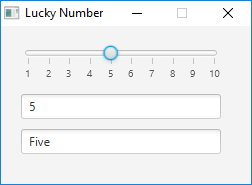

Each view of the number also allows the user to change the number, and the change is immediately reflected in all views.

A naive (and inferior) way to implement this functionality is through *complete pairwise dependencies*.

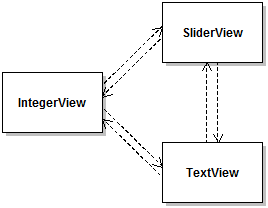

This design suffers from (at least) the following three inter-related limitations:

- **High coupling**: Each panel explicitly depends on many other panels.
- **Complexity**: Complex idiosyncratic program logic is required to keep the different panels consistent.
- **Low Extensibility**: To add or remove a panel, it is necessary to modify all other panels.

Furthermore, these limitations all increase quadratically in the number of panels, given that there are `n*(n-1)` directed edges in a complete graph with `n` vertices.

The way out of this nauseating approach is to separate program elements responsible for *storing state* from program elements responsible for *viewing state*, from program elements responsible for *changing state*, and to use various mechanisms to achieve loose coupling between these. This profoundly influential idea is commonly known as **the Observer Design Pattern** or (somewhat alternatively) **the Model-View-Controller** architecture (MVC). In this book I stick to the "Observer pattern" terminology, but it's good to be aware that in other contexts people may talk about the MVC and refer to essentially the same thing.

### 6.3.2 The Observer Design Pattern

The central idea of the Observer design pattern is to store state of interest in specialized objects, and to allow other objects to *observe* this state. The class diagram below illustrates how this is realized for the LuckyNumber application.

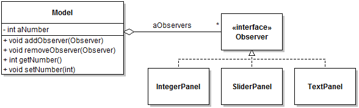

In this situation, the object in charge of keeping state is an instance of `Model`. The `Model` class in the Observer design pattern can alternately be called "Subject", or even "Observable". Here an instance of `Model` simply keeps track of an integer and allows clients to query and mutate this integer. Where things become interesting is that the `Model` class also includes an aggregation to an `Observer` interface, with methods to add and remove `Observer` instances from its collection. This is also called *(de)registering* observers. Classes that define objects that would be interested in observing the state of the model must then declare to implement the `Observer` interface. Through polymorphism, we thus achieve loose coupling between the model and its observers. Specifically:

- The model can be used without any observer;
- The model is aware that it can be observed, but its implementation does not depend on any concrete observer class.
- It is possible to register and de-register observers at run-time.

Two key questions about the relation between a model an its observers are:

- How do the observers learn that there is new information in the model that they need to know about?
- How do they access this information?

The answer to the first question is that whenever the model determines that there is a change in the model worth reporting to observers, it cycles through the observers and calls a certain method on them. This method has to be defined on the `Observer` interface and is usually called a "callback" because of the inversion of control that it represents. We talk of inversion of control because to find out information from the model the observers do not call a method on the model, they instead "wait" for the model to call them (back). This is often referred to as the "Hollywood Principle" ("don't call us, we'll call you"). That is also why the method that is called by the model on the observer is called a "callback". The following sequence diagram illustrates what happens when we change the model on the "LuckyNumber" application.

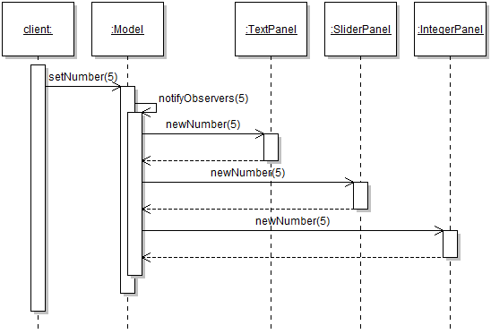

Here, inside the state-changing method `setNumber(int)`, we added logic to loop through each observer and call the method `newNumber` on each. This `newNumber` method is a "callback" that the observers will expect to be called every time there is a state change in the model. The implementation of the callback dictates how each observer reacts to the change in state.

Another way to think about callback methods is as "events", with the model being the "event source". With this paradigm, the model generates a series of "events" that correspond to different state changes, and other objects are in charge of reacting to these events. What events correspond to in practice is simply methods calls.

The figure below provides a summary of the main roles of the Observer pattern and their relation.

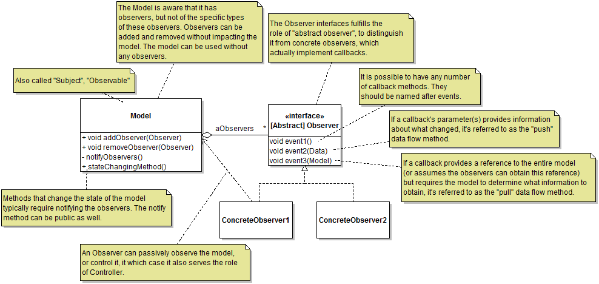

Variation points for the Observer design pattern include:

- Whether to make the `notifyObserver` methods public or private. If public, clients with references to the model get to control when notifications are issued. If private, it is assumed that the method is called at appropriate places in the state-changing methods of the model.
- What callbacks methods to define on an abstract observer. An abstract observer can have any number of callbacks that can correspond to different types of events.
- What data flow strategy to use to move data between the model and observers (push, pull, none, or both, as appropriate).
- Whether to use a single abstract observer or multiple ones. Multiple abstract observers with different combinations of callbacks give clients more flexibility to respond to certain events or not.
- How to couple observers with the model if observers need to query or control the model. Here the use of the interface segregation principle is recommended.

### 6.3.3 Observer Design Case Study

Let's consider how we would approach the following question:

> We are interested in an inventory system capable of keeping track of electronic equipment. An `Item` of equipment records a serial number (`int`) and production year (`int`). An `Inventory` object aggregates a bunch of `Item`s. Clients can add or remove `Item`s from the `Inventory` at any time. Various entities are interested in changes to the state of the `Inventory`. For example, it should be possible to show the items in the `Inventory` in a `ListView`. It should also be possible to view a `PieChart` representing the proportion of `Item`s in the `Inventory` for each production year (e.g., 2004=25%; 2005=30%, etc.). Views should be updated whenever items are added or removed from the Inventory.

As a first take on this problem we can model the basic elements of the domain with a class diagram:

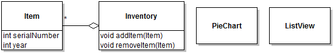

This diagram captures all the relevant domain elements but, little else. The following step is to instantiate a basic Observer pattern. At this stage this simply requires realizing which domain object plays which role. Here the object containing the observable state would be instances of `Inventory`, and the objects observing this state would be `PieChart` and `ListView`.

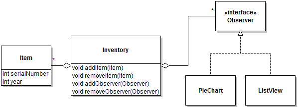

Now the basic mechanism for linking observers with the `Inventory` is visible, but some of the interesting questions are left unanswered. At this point we need to design callback methods. Since there are only two possible events in this simple problem (adding and removing items), there are two choices for callbacks:

- A single callback that indicates that an item was added or removed;
- One callback for items added and one for items removed.

Here the first option would end up being called something like `itemAddedOrRemoved` and concrete observer would have to check a boolean flag to determine what happened. This option clearly has the smell of being not quite right. Indeed the second one is the more elegant choice. The next question is how to tell observers which item has been added or removed. Using the pull strategy , we could include a reference to the `Inventory` that changed as part of the callback, and add a method `getLastItemAddedOrRemoved()`:

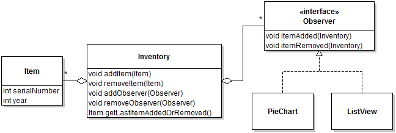

Although technically workable, this solution both looks and is clumsy. A much more natural option here seems to be to simply pass the added/removed item to the callback, to have something like `itemAdded(Item)`. Another somewhat more radical option, is to make the `Inventory` `Iterable<Item>` and to expect the observers to refresh themselves completely every time they receive an event. In some cases this make sense, but here let's stick to the use of the push strategy.

The last question is how to trigger notifications. Here we'll choose to add a private `notifyObservers` method that is automatically called whenever `addItem` or `removeItem` is called.

The current class diagram is thus:

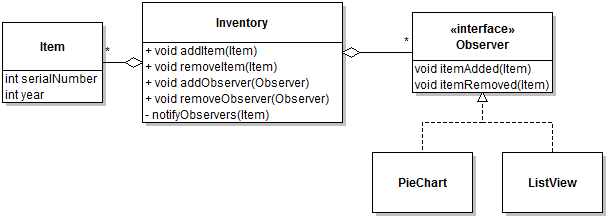

Assuming two observers (one of each type) are registered with the inventory, a sequence that illustrates an item being added is thus:

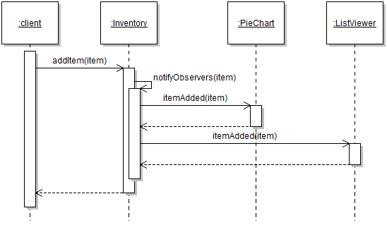

Note the following details:

- The `notifyObservers` method takes in a parameter to facilitate its implementation.
- The names of the methods on the `Observable` describe *commands* such as `addItem`, whereas the names of the call back describe the corresponding *result of the command as an event in the past*, such as `itemAdded`. The use of effective names greatly contributes to the usability of the Observer pattern.

Finally, let's assume that after using this design in a version of the system, a new type of observer is added, called the `TransactionLogger`. This type of observers is only interested in items being added to the inventory. In the current design, the class would have to implement the `itemRemoved` callback to do nothing. In this case, we can improve the design to allow different types of observers to register to only the events they care about. However, note that this doubles the number of observer management methods on the model.

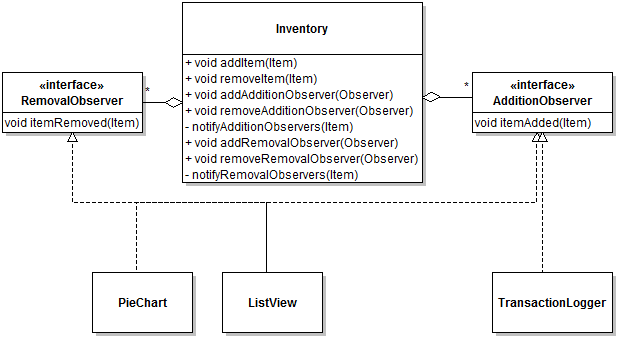

### 6.3.4 General Introduction to GUI Development with JavaFX

The code that implements the Graphical User Interface (GUI) portion of an application makes heavy use of the Observer design pattern. This section of Module 6 is a brief introduction to GUI programming that serves the dual purpose of being a first approach to GUI frameworks and reinforcing your knowledge of the Observer pattern through its application in practice. This part of the module relies on [JavaFX](http://www.oracle.com/technetwork/java/javafx/overview/index.html), a modern and extensive GUI framework for the Java language. However, the general concepts presented here should apply to practically any GUI development framework.

Conceptually the three essential components of a GUI application are:

- **Component Graph:** The "actual" interface is comprised of a number of objects that represent both visible (e.g., buttons and invisible (e.g. regions) elements of the application. These objects are typically organized as a tree, with the root of the tree being the "top" (or main) window or area of the GUI. In modern GUI frameworks, constructing a component graph can be done by writing code, but also through configuration files generated by GUI building tools. Ultimately the two are equivalent, because once the program runs the result is the same: a tree of plain Java objects that form the user interface. The design of the library classes that support the construction of a component graph makes heavy use of polymorphism, the Composite design pattern, and the Decorator design pattern.
- **Framework Event Loop:** A GUI application does not starts the same way as a "plain" program (i.e., through a `main` method explicitly passed as argument to the execution environment). Instead, the application is started by *launching* the GUI framework. The framework is then responsible for instantiating the component graph, and then starting an "event loop". The event loop is a functionality of the framework whereby the framework monitors events triggered by input devices (e.g., moving the mouse) and automatically maps these low-level events into specific interactions with components in the graph (e.g., mousing over a text box, clicking a button).
- **Event Handling:** A GUI framework executes application-specific code by executing callback methods defined by the application developers. In this sense, GUI events are essentially a manifestation of state change notifications in the Observer design pattern.

Given these three concepts, we can summarize that creating and executing a GUI application involves three basic steps: defining the component graph, defining event handlers and registering them with events of interests on objects in the component graph, and starting the framework.

#### 6.3.4.1 The Component Graph

The component graph can be seen from four different perspectives (old image using Swing, to be updated eventually):

[figure not shown]

In JavaFX, the type hierarchy available to define component is extensive; the following is an incomplete simplification:

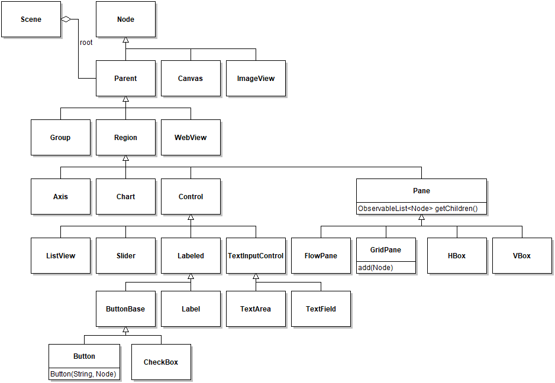

The following code from the [LuckyNumber sample](https://github.com/prmr/SoftwareDesignCode/tree/master/module06/ca/mcgill/cs/swdesign/m6/LuckyNumber.java) shows the construction of a component graph:

```java
@Override
public void start(Stage pPrimaryStage)
{
   ...
   GridPane root = createPane(); // The root of the GUI component graph
   root.add(new SliderPanel(model), 0, 0, 1, 1);
   root.add(new IntegerPanel(model), 0, 1, 1, 1);
   root.add(new TextPanel(model), 0, 2, 1, 1);
   ...
   pPrimaryStage.setScene(new Scene(root));
   ...
}

private static GridPane createPane()
{
   GridPane root = new GridPane();
   root.setHgap(GAP);
   root.setVgap(GAP);
   root.setPadding(new Insets(MARGIN));
   return root;
}
```

#### 6.3.4.2 The Framework and Event Loop

Frameworks differ from libraries in an essential way: they control the flow of the program and only call into application (i.e., developer-defined) code when they "decide". For this reason frameworks follow a paradigm called "inversion of control". Inversion of control is directly related to the observer pattern, since the framework determines when GUI elements (the subjects) trigger notification to their observers (the event handlers).

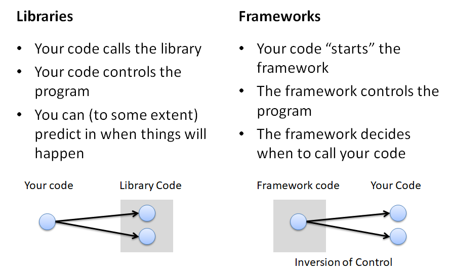

When the framework runs, the following loops executes ad infinitum:

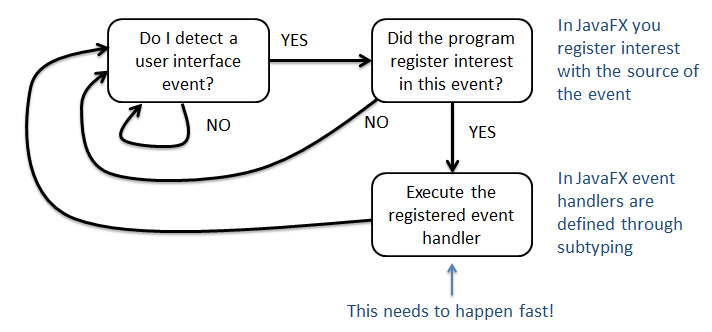

The following code from the [LuckyNumber sample](https://github.com/prmr/SoftwareDesignCode/tree/master/module06/ca/mcgill/cs/swdesign/m6/LuckyNumber.java) shows how the framework is launched:

```java
public static void main(String[] pArgs)
{
   launch(pArgs);
}

@Override
public void start(Stage pPrimaryStage)
{
   pPrimaryStage.show();
}
```

Here the `main` method does not start executing the application code: instead, it simply calls the static method `Application.launch`. This method executes a number of background tasks and, when it is ready, it calls the `start` method (the `start` method is, in that sense, a callback). As shown above, the `start` method builds the component graph and, once that's done, it calls `show` on the object that represents the top-level GUI element, at which point the GUI application becomes visible and reactive.

#### 6.3.4.3 Event Handling

In GUI frameworks objects in the component graph act as subjects in the observer pattern. For example, in the [LuckyNumber sample](https://github.com/prmr/SoftwareDesignCode/tree/master/module06/ca/mcgill/cs/swdesign/m6/LuckyNumber.java) the code:

```java
aText.setOnAction(new EventHandler<ActionEvent>()
{
   @Override
   public void handle(ActionEvent pEvent)
   {
      int lInteger = 1;
      try
      {
         lInteger = Integer.parseInt(aText.getText());
      }
      catch(NumberFormatException pException )
      {
         // Just ignore. We'll use 1 instead.
      }
      aModel.setNumber(lInteger);
   }
});
```

creates an instance of an anonymous class that is a subtype of `EventHandler<ActionEvent>` to handle the case where a user presses "Enter" when the cursor is on the text field. To register this handler with the source of the event, a reference to the instance is immediately provided as argument to the method `setOnAction` method of class `TextField`. This `setOnAction` method is the equivalent to `addObserver` in the observer design pattern. Note that it is possible to pass *any* instance of `EventHandler<ActionEvent>` to `setOnAction`. For example, another common design idiom is to define the class that contains the button (here `IntegerPanel`) to itself be the handler. For this to be possible, the class needs to implement `EventHandler<ActionEvent>` and provide a `handle` method. Once that's done, it's then possible to pass `this` to `setOnAction`.

## 6.4 Reading

- The [Module 6 code samples](https://github.com/prmr/SoftwareDesignCode/tree/master/module06/ca/mcgill/cs/swdesign/m6/LuckyNumber.java)
- The [JavaFX Tutorial](http://docs.oracle.com/javafx/2/get_started/hello_world.htm)
- Solitaire v0.3 The [DeckView](https://github.com/prmr/Solitaire/blob/v0.3/src/ca/mcgill/cs/stg/solitaire/gui/DeckView.java) class as an example of a GUI observer.

## 6.5 Exercises

Exercises prefixed with :star: are optional, more challenging questions aimed to provide you with additional design and programming experience. Exercises prefixed with :spades: will incrementally guide you towards the ultimate completion of a complete Solitaire application.

For maximum learning effectiveness, I recommend peeking at the answers only after giving the problems an honest try.

1. Extend the code of the [LuckyNumber](https://github.com/prmr/SoftwareDesignCode/tree/master/module06/ca/mcgill/cs/swdesign/m6/LuckyNumber.java) sample application to include a Roman Numerals panel.
2. Re-write the code of the [LuckyNumber](https://github.com/prmr/SoftwareDesignCode/tree/master/module06/ca/mcgill/cs/swdesign/m6/LuckyNumber.java) sample application so that data flows between the model and the observers using the pull strategy. Create a class diagram and a sequence diagram that model the key aspects of this solution.
3. Write the code that implements a skeleton application that corresponds to the Observer Design Case Study. Write a driver program that adds and removes item to make sure everything works as expected.
4. Study the code of the [Solitaire](https://github.com/prmr/Solitaire/tree/v0.4) application to see how the `GameModelListener` interface is used. Create a class diagram and a sequence diagram to document how the observer pattern is used in relation to the `GameModel` class.
5. Write a JavaFX application with a button and a label, which writes the current date and time in the label every time the button is pressed. You can obtain the current date and time with the following API call `LocalDateTime.now().toString();`
6. Re-write the code of the [LuckyNumber](https://github.com/prmr/SoftwareDesignCode/tree/master/module06/ca/mcgill/cs/swdesign/m6/LuckyNumber.java) sample application to add a "Notify" button that notifies observers of the value in the model. The value should only be propagated when the button is clicked.
7. Study the code of the [Solitaire](https://github.com/prmr/Solitaire/tree/v0.4) application to see how the `DiscardPileView` relies on the observer design pattern to respond to GUI events, and also updates to the model. Draw a class diagram and a sequence diagram to capture the information you discover.

## 6.6 Answers

Answers and answer sketches to the Module 6 practice exercises.

### 6.6.1 Exercise 1

The easiest solution is to copy class `TextPanel` to something like `RomanPanel` and to update the string literals from English to Roman numerals (e.g., "Two" becomes "II"). You can leave zero as is, since the Romans were unaware of this concept (and the string for zero is not displayed anyways). To add the panel to the application, simply add this statement at the appropriate place in method `start`:

```java
root.add(new RomanPanel(model), 0, 3, 1, 1);
```

The point of this exercise was to demonstrate how the Observer pattern makes it very easy to add/remove views without affecting the rest of the code.

### 6.6.2 Exercise 2

The main change is that the callback no longer has a parameter. This requires documenting how the concrete observers can access the model data. In the diagram this is represented by the aggregation to the `Model` and the parameter in the constructor, which clarifies how this aggregation is acquired. The other concrete observers are left out without loss of generality.

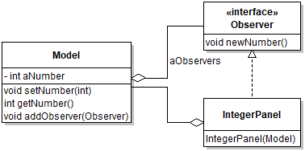

In the code, besides updating the signature of the callback method, the number in the model needs to be accessed from the reference to the model, for example in `IntegerPanel`:

```java
@Override
public void newNumber()
{
   aText.setText(new Integer(aModel.getNumber()).toString());
}
```

The sequence required to update the observers becomes a bit more complex:

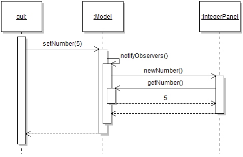

### 6.6.3 Exercise 3

The minimal code to exercise all parts of the pattern is shown below. The skeleton implements the last version of the design discussed in the case study.

```java
public class Inventory
{
    private List<Item> aItems = new ArrayList<>();
    private List<AdditionObserver> aAdditionObservers = new ArrayList<>();
    private List<RemovalObserver> aRemovalObservers = new ArrayList<>();

    public static void main(String[] args)
    {
        Inventory inventory = new Inventory();
        PieChart pieChart = new PieChart();
        ListView listView = new ListView();
        TransactionLogger logger = new TransactionLogger();
        inventory.addAdditionObserver(pieChart);
        inventory.addAdditionObserver(listView);
        inventory.addAdditionObserver(logger);
        inventory.addRemovalObserver(pieChart);
        inventory.addRemovalObserver(listView);

        Item item1 = new Item("Stapler");
        Item item2 = new Item("Toaster");
        inventory.addItem(item1);
        inventory.addItem(item2);
        inventory.removeItem(item1);
    }

    public void addAdditionObserver( AdditionObserver pObserver )
    {
        aAdditionObservers.add(pObserver);
    }

    public void addRemovalObserver( RemovalObserver pObserver )
    {
        aRemovalObservers.add(pObserver);
    }

    public void addItem(Item pItem)
    {
        aItems.add(pItem);
        notifyAdditionObservers(pItem);
    }

    public void removeItem(Item pItem)
    {
        aItems.remove(pItem);
        notifyRemovalObservers(pItem);
    }

    private void notifyAdditionObservers(Item pItem)
    {
        for( AdditionObserver observer : aAdditionObservers )
        {
            observer.itemAdded(pItem);
        }
    }

    private void notifyRemovalObservers(Item pItem)
    {
        for( RemovalObserver observer : aRemovalObservers )
        {
            observer.itemRemoved(pItem);
        }
    }
}

interface AdditionObserver
{
    void itemAdded(Item pItem);
}

interface RemovalObserver
{
    void itemRemoved(Item pItem);
}

class Item
{
    private String aName;

    public Item(String pName)
    {
        aName = pName;
    }

    @Override
    public String toString()
    {
        return aName;
    }
}

class PieChart implements AdditionObserver, RemovalObserver
{
    @Override
    public void itemRemoved(Item pItem)
    {
        System.out.println("Removed " + pItem + " from PieChart");
    }

    @Override
    public void itemAdded(Item pItem)
    {
        System.out.println("Added " + pItem + " to PieChart");
    }
}

class ListView implements AdditionObserver, RemovalObserver
{
    @Override
    public void itemRemoved(Item pItem)
    {
        System.out.println("Removed " + pItem + " from ListView");
    }

    @Override
    public void itemAdded(Item pItem)
    {
        System.out.println("Added " + pItem + " to ListView");
    }
}

class TransactionLogger implements AdditionObserver
{
    @Override
    public void itemAdded(Item pItem)
    {
        System.out.println("Logged addition of " + pItem) ;
    }
}
```

### 6.6.4 Exercise 4

The class diagram. A useful variant would be to add dependencies between concrete observers (e.g., `DeckView`) and the `GameModel`, since the callbacks mostly access the game model.

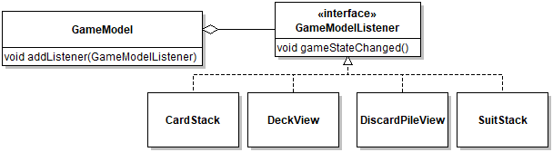

The sequence diagram starts the sequence with a "client" calling `perform` on a `CardMove` target. This happens in the GUI code. Note that the model leaves out numerous details, among others the non-trivial logic in `GameModel.move(...)`, so as to focus on illustrating the behavior relevant to the observer pattern. Many instances of `GameModelListener` are left out to avoid cluttering the diagram.

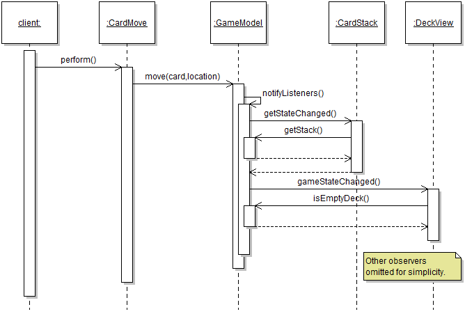

### 6.6.5 Exercise 5

The no-frills code below gets the job done. A variant using a lambda expression as handler is shown in comments.

```java
public class DateButton extends Application
{
   public static void main(String[] pArgs)
   {
      launch(pArgs);
   }

   @Override
   public void start(Stage pPrimaryStage)
   {
      Button button = new Button(LocalDateTime.now().toString());
      button.setOnAction(new EventHandler<ActionEvent>()
      {
         @Override
         public void handle(ActionEvent arg0)
         {
            button.setText(LocalDateTime.now().toString());
         }
      });

      // Does exactly the same as the above statement, but using a lambda expression.
      // button.setOnAction((e) -> button.setText(LocalDateTime.now().toString()));

      pPrimaryStage.setScene(new Scene(button));
      pPrimaryStage.show();
   }
}
```

# 7 Module 7 - Inheritance

## 7.1 Description

*Inheritance* is a programming language-supported mechanism that allows us to assemble state and computation from different classes into a single object. It is a powerful feature that offers a natural solution to many design problems related to code extensibility and dynamic configuration. At the same time, it is a complex mechanism that can all too easily be misused. In this module, I will offer a review of inheritance and present the major design rules and patterns involving it.

## 7.2 Learning Objectives

After this module you should:

- Have a deep understanding of the motivation for and conceptual foundations of inheritance;
- Be able to create class hierarchies that involve inheritance;
- Know about common problems with inheritance and how to avoid them;
- Be able to use the Template Method Design Pattern effectively;

## 7.3 Notes

### 7.3.1 Review of Inheritance

So far we have seen many situations where we can leverage polymorphism to realize various design features. Generally speaking polymorphism makes a design *extensible* and *reusable*. For example, the small design below is extensible because it is possible to add new types of employees without disrupting the existing design. Similarly, features that work with one type of employee can be reused on other types of employees.

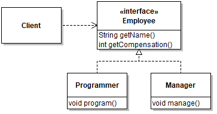

However, one limitation of this design becomes immediately apparent when we try to implement it. In this design, the root of the type hierarchy is an interface, so it defines services without providing an implementation for them. However, the kinds of services it defines, such as being able to return a name for an employee, are likely to be implemented in an identical way in each class. For example:

```java
public class Programmer implements Employee
{
   private String aName;
   private int aSalary;
   ...

public class Manager implements Employee
{
   private String aName;
   private int aSalary;
   private int aBonus;
   ...
```

So here we can say that the design induces *code duplication*, which is generally not desirable. There is an extensive literature on the topic of [code clones](https://en.wikipedia.org/wiki/Duplicate_code), but the bottom line is that they should be avoided.

One programming language mechanism readily available to avoid code duplication is *inheritance*. In Java and similar languages, inheritance allows programmers to define a class (the subclass) with respect to a base class (or superclass). This avoids repeating declarations of class members, since the declarations of the base class will be automatically taken into account when creating instances of the subclass.

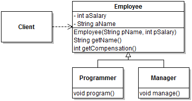

In UML, inheritance is denoted by a *solid line* with a white triangle pointing from the subclass to the superclass. In Java the subclass-superclass relation is declared using the `extends` keyword:

```java
public class Manager extends Employee
{
   private int aBonus;
```

To understand the effect of inheritance on a program, it's important to remember that a class is essentially a *template for creating objects*. Defining a subclass (e.g., `Manager`) as an extension of a superclass (e.g., `Employee`) means that when objects of the subclass are instantiated, the objects will be created by using all the declarations of the subclass and all of its superclasses. The result will be a *single* object. The run-time type of this object will be the type specified in the `new` statement. However, just like interface implementation, inheritance induces a suptyping relation. For this reason, an object can always be assigned to a variable of any of its superclasses (in addition to its implementing interfaces):

```java
Employee alice = new Manager();
```

In the code above, a new object of (run-time) type `Manager` is created and assigned to a variable named `alice` of (compile-time) type `Employee`. This is legal because `Manager` is a subtype of `Employee`, just as in the initial case with the interface. Note that when an instance of `Manager` is assigned to a variable of type `Employee`, it does not "become" an employee or "lose" any of the manager-specific fields. In Java, once an object is created, its run-time type remains unchanged, and in this example it would be possible to safely assign the object back to a variable of type `Manager`:

```java
Manager manager = (Manager) alice;
```

In this module, the distinction between **compile-time** type and **run-time** type will become increasingly important. The run-time type of an object is the (most specific) type of an object when it is instantiated. It is the type mentioned in the `new` statement, and the one that is represented by the object returned by method `getClass()`. The run-time type of an object never changes for the duration of the object's life-time. In contrast, the compile-time (or static) type of an object is the type of the *variable* in which an object is stored at a particular point in the code. In a correct program the static type of an object can correspond to its run-time type, or to any supertype of its run-time type. The static type of an object can be different at different points in the program, depending on the variables in which an object is stored. Consider the following example:

```java
1  public static boolean isManager(Object pObject)
2  {
3     return pObject instanceof Manager;
4  }
5
6  public static void main(String[] args)
7  {
8     Employee alice = new Manager();
9     Manager manager = (Manager) alice;
10    boolean isManager1 = isManager(alice);
11    boolean isManager2 = isManager(manager);
12 }
```

Here at line 8 an object is created that is of run-time type `Manager` and assigned to a variable of (static) type `Employee`. As stated above, the run-time type of this object remains `Manager` throughout the execution of the program. However, at line 9 the static type of the object is `Manager`, and at line 3 it is `Object` (a formal parameter is a kind of variable, so the type of a parameter acts like a type of variable).

### 7.3.2 Inheriting Fields

With inheritance, the subclass *inherits* the declarations of the superclass. Conceptually, the consequences of inheriting field declarations are quite different from those of method declarations, so we will discuss these separately.

Field declarations define state held by the instantiated object. When creating a new object, the object created will have a field for each field declared in the class named in the `new` statement, and each of its superclass, transitively. Given the following class hierarchy:

```java
class Employee
{
   private String aName;
   private int aSalary;
   ...

class Manager extends Employee
{
   private int aBonus;
   ...
```

object created with the statement:

```
new Manager(...);
```

will have three fields: `aName`, `aSalary`, and `aBonus`. Note that it does not matter that the fields are private. Accessibility is a *static* concept: it is only relevant to the source code. The fact that the code in class `Manager` cannot see (or access) the fields declared its superclass does not change anything to the fact that these fields are inherited. For the fields to be accessible in subclasses, it is possible to declare them `protected` or to access their value through an accessor method (a.k.a. "getter"). In Java, type members declared to be `protected` are only accessible within methods of the same class, classes in the same package, and subclasses in any package.

The inheritance of fields creates an interesting problem of data initialization. When an object can be initialized with default values, the process is simple. In our case, if we assign the default values as follows:

```java
class Employee
{
   private String aName = "Anonymous";
   private int aSalary = 0;
   ...

class Manager extends Employee
{
   private int aBonus = 0;
   ...
```

We can expect that creating a new instance of class `Manager` will result in an instance with three fields with the specified values. However, it is often the case that object initialization requires input data (e.g., an actual name for the employee and/or manager). In this case it becomes important to pay attention to the order in which the fields of an object are initialized. The general principle is that (in Java) the fields of an object are initialized "top down", from the field declarations of the most general superclass down to the specific class named in the `new` statement. In our example, `aName` would be initialized, then `aSalary`, and then `aBonus`. This order is achieved simply by the fact that the first instruction of any constructor is to call the constructor of its superclass, and so on. For this reason, the order of constructor calls is "bottom up".

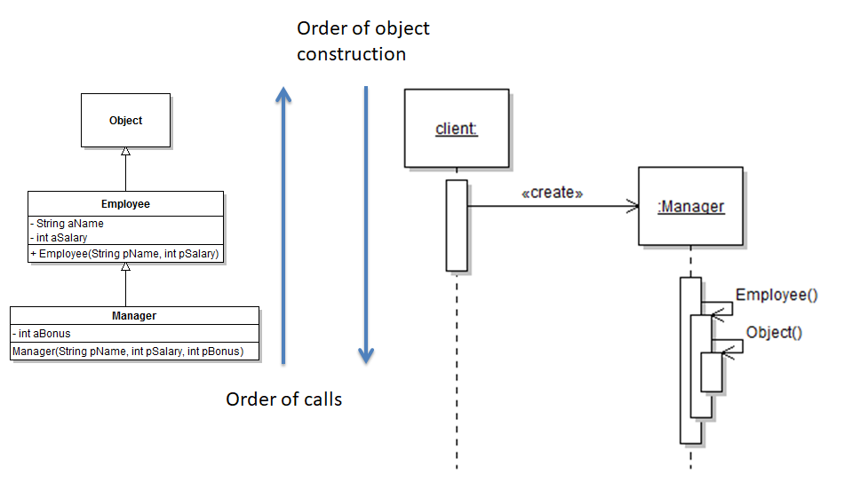

In Java, it is important to know that if *no constructor is declared*, a default constructor with no parameter is invisibly made available. For this reason, the fact that the first line of any constructor is the call to the super-constructor can be *implicit*. In the running example, declaring:

```java
class Manager extends Employee
{
   private int aBonus = 0;

   public Manager(int pBonus)
   { // Automatically calls super()
      aBonus = pBonus.
```

means that the default constructor of `Employee` is called and terminates before the code of the proper `Manager` constructor executes. With this constructor chain, it then becomes relatively easy to pass input values "up" to initialize fields declared in a superclass. For example:

```java
class Employee
{
   private String aName = "Anonymous";
   private int aSalary = 0;

   public Employee(String pName, int pSalary)
   {
      aName = pName;
      aSalary = pSalary;
   }
   ...

class Manager extends Employee
{
   private int aBonus = 0;

   public Manager(String pName, int pSalary, int pBonus)
   {
      super(pName, pSalary);
      aBonus = pBonus;
```

Here the first line of the `Manager` constructor is an *explicit* call to the constructor of the superclass, that passes in the initialization data. This explicit call is now actually required, because declaring a non-default constructor in `Employee` disables the automatic generation of a default constructor. Once the `super` call terminates, the initialization *of the same object* continues with the assignment of the `aBonus` field. Note that calling the constructor of the superclass with `super()` is *very different* from calling the constructor of the superclass with a `new` statement. In the latter case, two different objects are created. The code:

```java
   ...
   public Manager(String pName, int pSalary, int pBonus)
   {
      new Employee(pName, pSalary);
      aBonus = pBonus;
   }
```

calls the default constructor of `Employee` (if available), then creates a new `Employee` instance, different from the instance under construction, immediately discards the reference to this instance, and then completes the initialization of the object. This code is problematic.

### 7.3.3 Inheriting Methods

Inheriting methods is different from fields because method declarations don't change anything to the state held by an object, and so don't involve any data initialization of an object. Instead, the inheritance of methods centers around the question of *applicability*. By default, methods of a superclass are applicable to instances of a subclass. For example, if we define a method `getName()` in `Employee`, it will be possible to call this method on an instance of `Manager`:

```java
Manager manager = new Manager(); // Inherits from Employee
manager.getName();
```

This "feature" is nothing special, and really is only a consequence of what a method represents and the rules of the type system. Remember that an instance method is just a different way to express a function that takes an object of its declaring class as its first argument. For example, the method `getName()` in `Employee`:

```java
class Employee
{
   private String aName = ...;

   public String getName()
   {
      return this.aName;
   }
}
```

is more or less equivalent to the static method:

```java
class Employee
{
   public static String getName(Employee pThis)
   {
      return pThis.aName;
   }
}
```

In the first case the function is invoked by specifying the target object *before* the call: `employee.getName()`. In this case we refer to the `employee` parameter as the *implicit parameter*. A reference to this parameter is accessible through the `this` keyword within the method. In the second case the function is invoked by specifying the target object as an *explicit* parameter, so *after* the call: `getName(employee)`. In this case to clear any ambiguity it is usually necessary to specify the type of the class where the method is located, so `Employee.getName(employee)`. What this example illustrates, however, is that methods of a superclass are automatically *applicable* to instances of a subclass because instances of a subclass can be assigned to a variable of any supertype. Because it is legal to assign a reference to a `Manager` to a parameter of type `Employee`, the `getName()` method is applicable to instances of any subclass of `Employee`.

In some cases, the methods inherited from a superclass do not quite do what we want. Assume that in our running example class `Employee` has a method `getCompensation()`:

```java
class Employee
{
   private protected aSalary = ...;
   ...
   public int getCompensation() { return aSalary; }
```

If in our problem space the compensation of a manager is their salary plus a bonus, the inherited method `getCompensation()` will not quite do what we want: the bonus will be missing. In such cases, it is usual to *redefine* or *override* the behavior of the inherited method by supplying an implementation in the subclass that only applies to instances of the (more specific, less general) subclasses. For example:

```java
class Manager extends Employee
{
   private int aBonus = ...;
   ...
   public int getCompensation()
   {
      return aSalary + aBonus;
   }
```

Overriding inherited methods has a major consequence on the design of an object-oriented program, because it introduces the possibility that multiple method implementations apply to an object that is the target of a method invocation. For example, in the code:

```java
int compensation = new Manager(...).getCompensation();
```

both `Employee.getCompensation()` and `Manager.getCompensation()` are applicable and can thus legally be used. How to choose? For the program to work, the programming environment (the JVM) must follow a consistent *method selection algorithm*. For overridden methods, the selection algorithm is relatively intuitive: when multiple implementations are applicable, the run-time environment selects the *most specific one* based on the *run-time type of the implicit parameter*. Again, the run-time type of an object is the "actual" class that was instantiated: the class name that follows the `new` keyword, or the class type represented by the object returned by a call to `Object.getClass()`. Because the selection of an overridden method relies on run-time information, the selection procedure is often referred to as *dynamic dispatch*, or *dynamic binding*. It is important to remember that type information in the source code is completely overlooked for dynamic dispatch. So, in this example:

```java
Employee employee = new Manager(...);
int compensation = employee.getCompensation();
```

the method `Manager.getCompensation()` would be selected, even though the static (compile-time) type of the target object is `Employee`.

In some cases it is necessary to by-pass the dynamic binding mechanism and link to a specific, statically-predictable method implementation. In Java however, for instance methods it is only possible to do so by referring to the implementation of a method that is being directly overridden. This exception to the usual dynamic binding mechanism is intended to support the common case where a method is overridden to provide behavior *in addition* to what the original method does. To illustrate this case in our `Manager`-`Employee` scenario, consider a variant of the design where field `aSalary` in `Employee` would be `private`. In this case redefining `getCompensation` in `Manager` is tricky, since a reference to `aSalary` would result in a compile-time access violation:

```java
class Manager extends Employee
{
   private int aBonus = ...;
   ...
   public int getCompensation()
   {
      // Cannot be replaced with return getCompensation() + aBonus;
      return aSalary + aBonus;
   }
```

In the revised design the only way to access the value of `aSalary` is to call method `getCompensation()` on an object of type `Employee` (or a subtype). In the case where the run-time type of the object is `Manager`, however, this will result in a stack overflow, since the method would recursively call itself without a termination condition.

The solution is to refer to the *specific implementation* of `getCompensation()` in class `Employee`. To do so we use the keyword `super` followed by a method name:

```java
public int getCompensation()
{
   return super.getCompensation() + aBonus;
}
```

### 7.3.4 Overloading Methods

As we saw above, overriding methods allows programmers to declare different versions of the same method, so that the most appropriate method will be selected at run-time based on the run-time type of the implicit parameter. Many programming languages (including Java) support another mechanism for specifying different implementations of the "same" method, this time by selecting the method based on the type of the *explicit* parameters. This mechanism is known as **overloading**. A typical example of overloading can be found in [math libraries](https://docs.oracle.com/javase/8/docs/api/java/lang/Math.html), which provide basic functions such as `abs` (absolute value) for arguments of different primitive types, such a `int` and `float`. Another typical application of overloading is for constructors (e.g., a default constructor and a constructor taking various arguments).

The important thing to know about overloading is that the selection of a specific overloaded method is based on the *static* type of the *explicit arguments*. The selection procedure is to find all *applicable* methods and to select the *most specific* one. Although overloading provides a convenient way to organize small variants of a general computation, the use of this mechanism can easily lead to hard-to-understand code, and I recommend not overloading methods except for widely used idioms (such as constructor overloading or library methods that support different primitive types).

### 7.3.5 Abstract Classes

Inheriting class member declarations helps us avoid code duplication. However, there are often situations where locating common class members into a single superclass leads to a class declaration that it would not make sense to instantiate. For example, the small design below is for a graphical editor. The design represents how different geometric figures can be represented in the software.

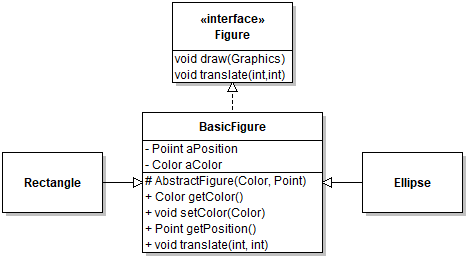

Because all figures have a position and a color, it makes sense to group all the related functionality into a common superclass `BasicFigure`. However, because `BasicFigure` implements the `Figure` interface, it must supply an implementation for all of the interface's methods, including `draw`. But how should we draw a `BasicFigure`? Here, even the idea of using some sort of default behavior seems questionable, because `BasicFigure` represents a purely abstract concept that needs to be refined to gain concreteness. This design situation is directly supported by the *abstract class* feature of a programming language. Technically, an abstract class represents a correct but incomplete set of class member declarations.

In Java a class can be declared abstract by including the reserved word `abstract` in its declaration. It is also common practice to prefix the identifier for an abstract class with the word `Abstract`. Hence, in our design the `BasicFigure` would be declared: `public abstract AbstractFigure implements Figure`.

Declaring a class `abstract` has three main consequences:

- The class cannot be instantiated, which is checked by the compiler.
- The class no longer needs to supply an implementation for all the methods in the interface(s) it declares to implement. This relaxing of the interface contract is type-safe because the class cannot be instantiated. However, any concrete (non-abstract) class will need to have implementations for all required methods.
- The class can declare new `abstract` methods, using the same `abstract` keyword, this time placed in front of a method signature. For example, adding `protected abstract Rectangle boundingBox();` within `AbstractFigure` will add a new abstract method to the class. Abstract methods are sometimes necessary to specify behavior that is required by the concrete methods of the abstract class, but whose implementation requires information that is only available in subclasses. The section on the Template Method design pattern, below, provides a detailed illustration of this scenario. From a program construction point of view, abstract methods work just like interface methods: any concrete subclass must provide an implementation for them to be instantiable.

Note that because abstract classes cannot be instantiated, their constructor can only be called from within the constructors of subclasses. For this reason it makes sense to declare the constructors of abstract classes `protected`.

### 7.3.6 Template Method Design Pattern

One not uncommon situation with inheritance is where some code is common for all subclasses, except for some small parts of an algorithm that vary from subclass to subclass. Because parts of the code is common, it will benefit from being "moved up" to the superclass so that it can be reused and so that the design is robust to errors caused by inconsistently re-implementing common behavior. However, because the code needs information from subclasses, it cannot be completely implemented in the superclass. The solution to this problem is to put all the common code in the superclass, and to define some "hooks" to allow subclasses to provide specialized functionality where needed. This idea is called the **Template Method design pattern**. The name relates to the fact that the common method in the superclass is a "template", that gets "instantiated" differently for each subclass. The "steps" are defined as non-private (so overridable) methods in the superclass.

Let's illustrate the situation with the example of `Figure.draw(Graphics)`, from the design in the above section. Assume that in that particular design, a figure is observable (in the sense of the Observer design pattern), and drawing a figure involves three three steps:

1. Invalidating the bounding box for the figure (so the canvas can be efficiently refreshed);
2. Actually drawing the figure (using graphics primitives such as `drawLine`, etc.);
3. Notifying observers that the figure was drawn.

Here the first and last steps *should always happen in the same way*, but obviously the second step will depend on the actual concrete figure. To realize a solution, we capture the first and third steps as private methods in `AbstractFigure` (`BasicFigure` on the diagram). Assume that the code to complete these two operations can be entirely written in the superclass. The code of the `AbstractFigure` class would thus start to look like:

```java
public AbstractFigure implements Figure
{
   private void invalidate() { /* Invalidate the bounding box */ }
   private void notifyObservers() { /* Call callback on all observers */ }

   public void draw(Graphics pGraphics)
   {
      invalidate();
      // Complete the drawing
      notifyObservers();
   }
```

The only remaining question is, how can we complete this code? The solution is to use an *abstract* method to make the code compile but delegate the implementation to subclasses. We would therefore add the following declaration within `AbstractFigure`:

```java
   protected abstract void drawFigure(Graphics pGraph);
```

which allows us to finish the code of `draw` so it compiles properly:

```java
public final void draw(Graphics pGraphics)
{
   invalidate();
   drawFigure(pGraphics);
   notifyObservers();
}
```

The implementation of the pattern will then need to be completed by concrete subclasses, which will have to supply an implementation for `drawFigure` that actually draws the figure on the graphics context.

The following are important to note about the use of the Template Method design pattern:

- The method in the abstract superclass is the *template* method, it calls the concrete and abstract *step methods*;
- If it is important that in a design the algorithm embodied by the template method be fixed, it could be a good idea to declare the template method `final`, so it cannot be overridden (and thus changed) in subclasses;
- It's important that the abstract step method has a different name from the template method for this design to work. Otherwise, the template method would recursively call itself, leading to a stack overflow;
- The most likely access modifier for the abstract step methods is `protected`, because in general there will likely not be any reason for client code to call individual steps that are intended to be internal parts of a complete algorithm. Client code would normally be calling the template method.
- The "steps" that need to be customized by subclasses do not necessarily need to be abstract. It some cases, it will make sense to have a reasonable default behavior that could be implemented in the superclass. In this case it might not be necessary to make the superclass abstract.

When first learning to use inheritance, the calling protocol between code in the super- and subclasses can be a bit confusing because, although it is scattered over multiple classes, the method calls are actually on the *same target object*. The following sequence diagram illustrates a call to `draw` on a hypothetical `Rectangle`. As can be seen, although it is implemented in subclasses, the call to the abstract step method is a self-call.

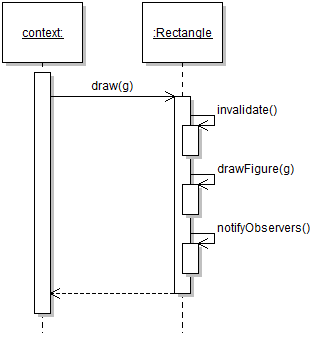

### 7.3.7 Proper Use of Inheritance

Inheritance is *both* a code reuse and an extensibility mechanism. This means that a subclass both inherits the declarations of its superclasses, but also becomes a subtype of the superclasses. To avoid major design flaws, inheritance should only be used for *extending* the behavior of superclasses. As such, it is incorrect to use inheritance to **limit or restrict** the behavior of the superclass, and/or to use inheritance **when the subclass is not a proper subtype** of the superclass.

A classic example of using inheritance incorrectly by limiting the behavior of the superclass is the so-called [Circle-ellipse problem](https://en.wikipedia.org/wiki/Circle-ellipse_problem), wherein a class to represent a circle is defined by inheriting from an `Ellipse` class and preventing clients from creating any ellipse instance that does not have equal proportions. The issue with this idea is that services that were available on instances of the superclass (ellipse) must become "invalid" or "unsupported" if the run-time instance happens to be of the subtype `Circle`:

```java
Ellipse ellipse = getEllipse();
ellipse.setHeight(ellipse.getWidth()*2); // Not possible if ellipse is an instance of Circle
```

This intuition is captured by the [Liskov substitution principle](https://en.wikipedia.org/wiki/Liskov_substitution_principle), which basically states that subclasses should not restrict what clients of the superclass can do with an instance. Specifically, this means that methods of the subclass:

- Cannot have stricter preconditions;
- Cannot have less strict post-conditions;
- Cannot take more specific types as parameters;
- Cannot make the method less accessible (e.g., public -> protected);
- Cannot throw more checked exceptions;
- Cannot have a less specific return type.

Somewhat related is the issue of (mis)using inheritance when composition should be used. Citing [Effective Java, 2nd Edition](https://www.safaribooksonline.com/library/view/effective-java-2nd/9780137150021/):

> Inheritance is appropriate only in circcumstances where the subclas really is a *subtype* of the superclass. In other words, a class B should only extend a class A if an "is-a" relationship exists between the two classes.

Some obvious (and acknowledged) violations of this principle include `java.util.Stack` (which inappropriately inherits from `Vector`), and `java.util.Properties` (which inappropriately inherits from `Hashtable`).

## 7.4 Reading

- [Java Tutorial on Inheritance](https://docs.oracle.com/javase/tutorial/java/IandI/subclasses.html)
- JetUML v1.0 The class hierarchy rooted at interface [Node](https://github.com/prmr/JetUML/blob/v1.0/src/ca/mcgill/cs/stg/jetuml/graph/Node.java)

## 7.5 Exercises

1. A bike courier company uses a Scheduler system to schedule bikers for delivery based on various factors (unimportant for this practice question). The company wants the flexibility to install different scheduling algorithms. However, all scheduling algorithms should follow these steps: (a) check if at least one biker is available, and if not throw an exception; (b) schedule a biker using a given algorithm; (c) notify interested observers that a biker was scheduled. Operations (a) and (c) are the same for all algorithms, but should be isolated in separate methods. Concrete schedulers should also have the flexibility to throw algorithm-specific types of exceptions if they cannot fulfill a scheduling request. Assume all exceptions for this design are checked. Complete the following UML class diagram to provide a design for these requirements. Use the TEMPLATE METHOD design pattern. When relevant to the design, make sure to include the appropriate modifiers for methods and/or classes (`final`, `public`, `protected`,`private`, `abstract`, etc.). Illustrate support for two different scheduling algorithms. Include the OBSERVER mechanism for biker notification. Write the code necessary to implement the relevant parts of your design.

# 8 Module 8 - Design Patterns

## 8.1 Description

This module will explore design solutions that incorporate design patterns an inheritance and introduce the Visitor design pattern.

## 8.2 Learning Objectives

After this module you should:

- Be able to use the Visitor Design Pattern effectively;
- Be able to determine when inheritance can be effectively used within different design patterns including the Visitor, Decorator, Composite, Command, and Strategy patterns.
- Be able to correctly instantiate design patterns with inheritance.

## 8.3 Notes

### 8.3.1 Visitor Design Pattern

### 8.3.2 Design Pattern Review Scenario

We will explore how to combine design patterns by creating a design for a hypothetical mobile robotics system. In this system, a `Robot` class represents a three-wheeled robot with two active wheels and one free wheel that can also rotate around a pivot. The `Robot` class provides very basic control primitives through a method `void moveLeftWheel(double pRadians)` a similar method for moving the right wheel, and a similar method for moving both wheels in synch. The `pRadians` parameter specifies how much to turn the wheel, e.g., `pRadians=2*PI` turns the wheel a full circle.

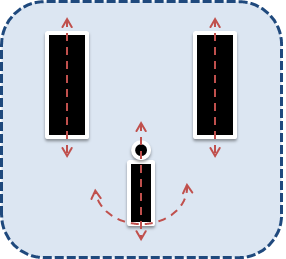

We want to expand this design to implement the following requirements:

1. It should be possible to define higher-level commands for the robot in terms of the basic primitives. For example it should be possible to define a "Forward Move" command that moves both wheels by the same amount. The number of different commands should be extensible;
2. Commands should be parameterizable, e.g., "move forward 1 meter" vs 2 meters, etc.
3. Any command should be reversible;
4. Commands should have a name that can be discoverable at run time. For example, a "Move forward 1 meter".
5. It should be possible to aggregate commands into more complex "macro commands". For example, a "Back and Forth" command could involve a forward move followed by a backward move.
6. It should be possible for components in the system other than the robot to be notified of commands issued on a `Robot` object. Three components interested in robot commands include a `CommandLogger` that prints all commands with a time stamp, `CommandRecorder` that can be issued a request to record commands (or to stop recording them), and to control the robot to replay the recording; a `RobotConsole` component that visually shows the path of the robot in a graphical user interface.
7. The system should remember the last command issued to a robot, and provide a convenience method `reexecute()` to re-execute this command. The reexecution of the command should be considered a new, separate command.

In addition to these requirements, the final design should exhibit a number of qualities: * Effective code reuse: the design should limit code duplication; * Loose coupling: classes should not depend on interfaces they do no need; * Robustness: The likelihood of `NullPointerExceptions` should be, well, null.

## 8.4 Reading

- [A webpage on the Visitor design pattern](https://en.wikipedia.org/wiki/Visitor_pattern)

## 8.5 Exercises

For maximum learning effectiveness, I recommend peeking at the answers only after giving the problems an honest try.

1. Add Visitor support to the class hierarchy below by completing the class diagram. Include a `PrintVisitor` as part of the design. Using a sequence diagram, show a scenario of a traversal through a directory object with the print visitor. The `PrintVisitor` prints the name of each file it visits. Implement a mock-up of the design in code, and use the debugger to validate your sequence diagram.

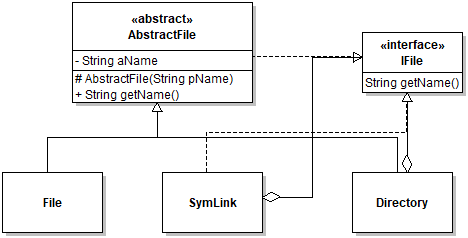

## 8.6 Answers

Answers and answer sketches to the Module 8 practice exercises.

Other variants are possible.

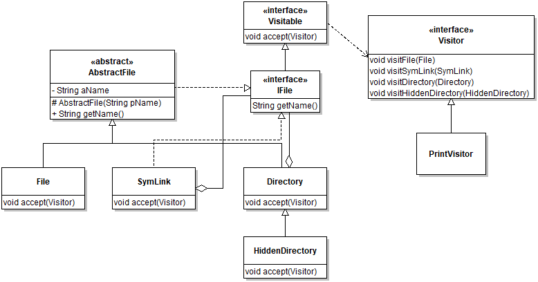

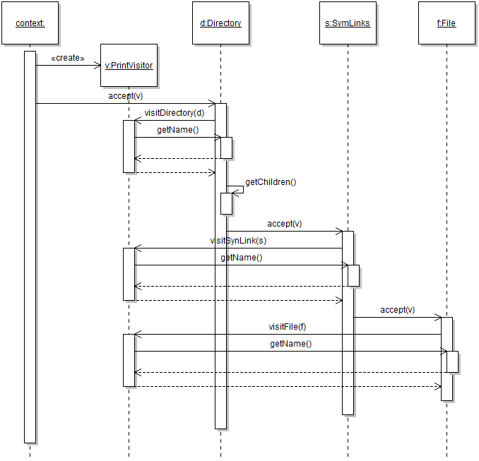

# 9 Module 9 - Concurrency

## 9.1 Description

*Concurrent programming* is a paradigm that allows developers to write code that can execute in parallel (on multi-core systems) or with the illusion of parallelism (on single-core ones). Concurrent programming is very, very challenging and is ideally only used in support of well-defined and well-understood design problems, such as performing background operations or displaying animations. In fact, many typical concurrent programming problems already have a framework-based solution that hides the use of concurrency primitives. In this module, I will present the foundations of object-oriented concurrent programming and a few examples of the use of concurrency in practice.

## 9.2 Learning Objectives

After this module you should:

- Understand the concept of a Thread and its usefulness for programming;
- Be able to write basic concurrent programs in Java;
- Understand the causes of basic concurrency errors including race conditions and deadlocks, and the mechanisms that help prevent them.
- Be able to recognize when to and when not to use concurrency in application design;

## 9.3 Notes

## 9.4 Reading

- [Java Tutorial - Concurrency](https://docs.oracle.com/javase/tutorial/essential/concurrency/)

## 9.5 Exercises

Exercises prefixed with :star: are optional, more challenging questions aimed to provide you with additional design and programming experience. For maximum learning effectiveness, I recommend peeking at the answers only after giving the problems an honest try.

## 9.6 Answers

### 9.6.1 Exercise 1

You need to synchronize class `Box` to avoid data races and to ensure the visibility of new values across threads.

```java
public class Box
{
    private final Lock lock = new ReentrantLock();

    private int aNumber = 0;

    public void increment()
    {
        lock.lock();
        try { aNumber ++; }
        finally { lock.unlock(); }
    }

    public int get()
    {
        lock.lock();
        try{ return aNumber; }
        finally { lock.unlock(); }
    }

    public static void main(String[] args)
    {
        final Box box = new Box();
        new Thread(new Runnable()
        {
            public void run()
            {
                while(true)
                {
                    box.increment();
                }
            }
        }).start();
        new Thread(new Runnable()
        {
            public void run()
            {
                try
                {
                    while(true)
                    {
                        System.out.println(box.get());
                        Thread.sleep(1000);
                    }
                }
                catch(InterruptedException e )
                {
                    return;
                }
            }
        }).start();
    }
}
```

### 9.6.2 Exercise 2

This version should print the sequence of positive integers, one per second.

```java
public class Box
{
    private final Lock lock = new ReentrantLock();
    private final Condition valueAvailable = lock.newCondition();

    private int aNumber = 0;

    public void increment()
    {
        lock.lock();
        try
        {
            aNumber ++;
            valueAvailable.signalAll();
        }
        finally { lock.unlock(); }
    }

    public int get()
    {
        lock.lock();
        try
        {
            valueAvailable.await();
            return aNumber;
        }
        catch( InterruptedException e )
        {
            return aNumber;
        }
        finally { lock.unlock(); }
    }

    public static void main(String[] args)
    {
        final Box box = new Box();
        new Thread(new Runnable()
        {
            public void run()
            {
                try
                {
                    while(true)
                    {
                        Thread.sleep(1000);
                        box.increment();

                    }
                }
                catch( InterruptedException e)
                {
                    return;
                }
            }
        }).start();
        new Thread(new Runnable()
        {
            public void run()
            {
                while(true)
                {
                    System.out.println(box.get());
                }
            }
        }).start();
    }
}
```

### 9.6.3 Exercise 3

While using a timer API would be superior, for this small exercise the following revised version of the `main` method will do the job:

```java
    public static void main(String[] args)
    {
        final Box box = new Box();
        final Thread counter = new Thread(new Runnable()
        {
            public void run()
            {
                try
                {
                    while(!Thread.interrupted())
                    {
                        Thread.sleep(1000);
                        box.increment();

                    }
                }
                catch( InterruptedException e)
                {
                    return;
                }
            }
        });
        final Thread printer = new Thread(new Runnable()
        {
            public void run()
            {
                while(!Thread.interrupted())
                {
                    System.out.println(box.get());
                }
            }
        });
        final Thread timer = new Thread(new Runnable()
        {
            public void run()
            {
                while( box.get() < 10 )
                {}
                counter.interrupt();
                printer.interrupt();
            }
        });
        timer.start();
        counter.start();
        printer.start();
    }
```

# 10 Module 10 - Serialization

## 10.1 Description

Sometimes, the data in a running program needs to be transferred out of the program, for example to be stored in a file or transmitted over a network. In this module, I will cover the main techniques for serializing object graphs using a variety of frameworks including Java's binary serialization and JavaBeans frameworks and JSON serialization APIs. This module will also conclude the course with an introduction to the agile development practice called refactoring.

## 10.2 Learning Objectives

After this module you should:

- Understand the basic problems and trade-offs related to the serialization of objects graphs;
- Be able to make an informed decision about the best serialization strategy for a given design situation;
- Be able to serialize simple object graphs in Java using JDK frameworks and a JSON API;
- Know about the concepts of code smells and refactoring
- Be able to recognize common bad smells in code;
- Be able to perform a selection of common object-oriented refactorings;

## 10.3 Notes

## 10.4 Reading

- Introduction to [the JSON format](http://json.org/);
- Documentation for [XMLEncoders](http://www.oracle.com/technetwork/java/persistence4-140124.html);
- JetUML v1.0 [PersistenceService](https://github.com/prmr/JetUML/blob/v1.0/src/ca/mcgill/cs/stg/jetuml/framework/PersistenceService.java) class as an example of XML serialization.
- Chapter 3 and descriptions of refactorings seen in class in Fowler's book

## 10.5 Exercises

Exercises prefixed with :star: are optional, more challenging questions aimed to provide you with additional design and programming experience.

1. Serialize the `Corporation` object created in `labtest01.Driver` using the four types of serialization seen in class. Note that saving the graph in CSV will require some hand-crafted encoding conventions, such as repeating field values. Using the debugger, inspect the deserialized object graph to investigate whether the sharing of the identity of `Item` objects is respected or not.
2. Once you have a file with the serialized version of the corporation in all four formats, add a boolean field to the `Item` class, for example `aOnSale`. Then, attempt to deserialize the saved versions. What happens then? Solve the problem for each technique using the most appropriate mechanism.
3. On the Solitaire sample application, use the Eclipse Extract Interface refactoring tool on Deck and extract the methods size and draw. Call the new interface `CardSource` for example. Notice how the tool automatically figures out that the interface to a `Deck` instance can be narrowed down to a `CardSource` in `WorkingStackManager`.

Unless otherwise noted, the content of this repository is licensed under a [Creative Commons Attribution-NonCommercial-NoDerivatives 4.0 International License](http://creativecommons.org/licenses/by-nc-nd/4.0/).

Copyright Martin P. Robillard 2017